# COMP140 Individual Creative Computing Project

Alcwyn Parker

18/01/2020

## Register Attendance

[figure not shown]

Attendance monitoring is in place. It is your responsability to ensure that you have signed yourself in.

## Learning Outcomes

After this session you will be able to:

- **Exlain** the difference between current, voltage, and resistance
- **Predict** the characteristics of basic circuits using simple formulas
- **Choose** components based on their purpose and characteristics

## What is current electricity?

(the stuff that makes our gadgets tick)

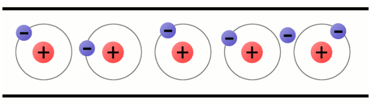

<sup>source:https://learn.sparkfun.com/tutorials/what-is-electricity/allrmar</sup>

- The flow of electrons through
- a closed circuit (wire, components, etc)
- Induced by an electric field (battery)

## Battery Example

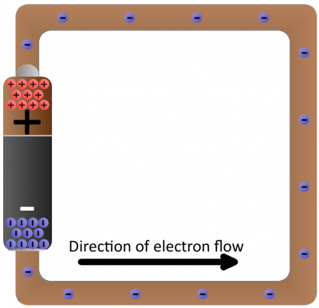

<sup>source:https://learn.sparkfun.com/tutorials/what-is-electricity/allrmar</sup>

## Basic characteristics

- **Voltage (V)** - The relative level of electrical energy between any two points in a circuit. Voltage is measured in *volts*.
- **Current (I)** - The amount of electrical energy passing through any point in a circui. Current is measured in *amps*
- **Resistence (R)** - The amount that any component in the circuit resists the flow of current. Resistence is measured in *ohms*

## Water Analogy

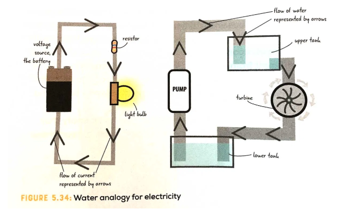

#### Hagan,J.(2017). Learn Electronics with Arduino. Maker Media, Inc

## Reading Schematic Diagrams

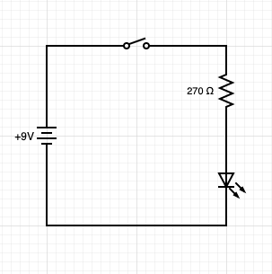

## The Rules

- Positive volatages are uppermost
- Things happen left to right
- All components have a name and values
- Remember symbols
- Dots show that the wires are connected:

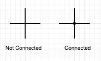

- Nets: Inferred connection based on symbol or name:

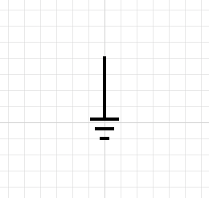

## Reading Schematic Diagrams (answer)

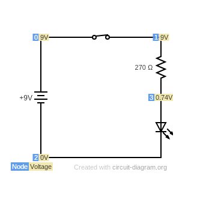

## Schematic Circuits 1

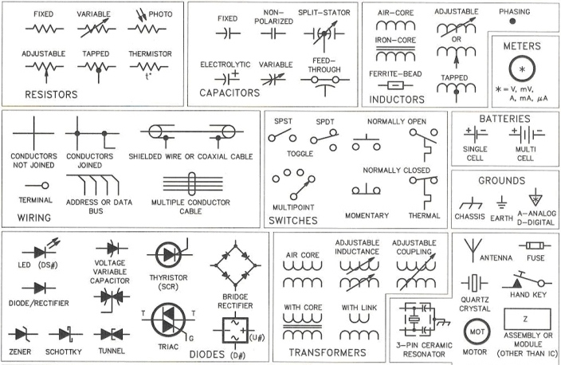

<sup>source:https://www.autodesk.com/products/eagle/blog/how-to-read-your-first-autodesk-eagle-schematic-like-a-pro-in-3-easy-steps</sup>

## Schematic Circuits 2

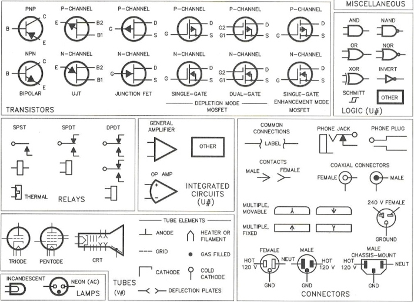

<sup>source:https://www.autodesk.com/products/eagle/blog/how-to-read-your-first-autodesk-eagle-schematic-like-a-pro-in-3-easy-steps</sup>

## Ohm’s Law

$I = V / R$

- If the voltage increases, whe the current (a) increase or (b) decrease.
- If the resistance increases will the current (a) increase or (b) decrease.

## Ohm’s Law Example 1

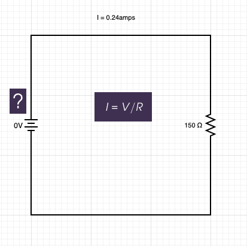

## Ohm’s Law Example 1 - Answer

$$I = V/R$$

$$0.24amps = ? / 150ohms$$
$$V = 0.24 * 150$$

Answer = 36 Volts

## Ohm’s Law Example 2

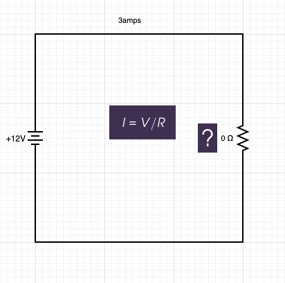

## Ohm’s Law Example 2 - Answer

$$I = V/R$$

$$3amps = 12volts / ?$$
$$R = 12 / 3$$

Answer = 4Ohms

## Resistors (Series vs. Parrallel)

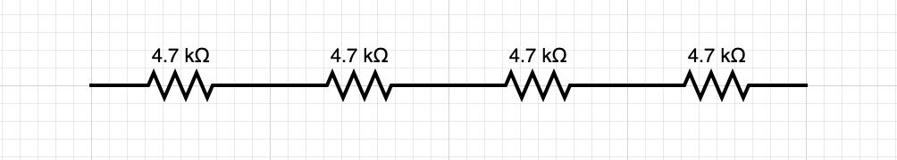

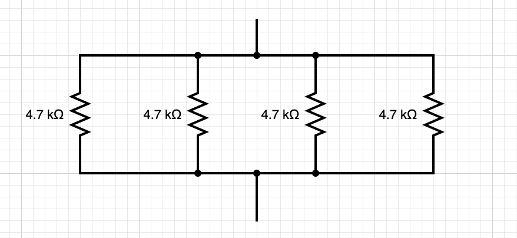

## Series

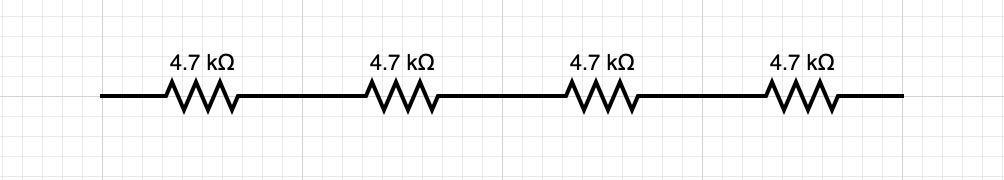

## Parallel

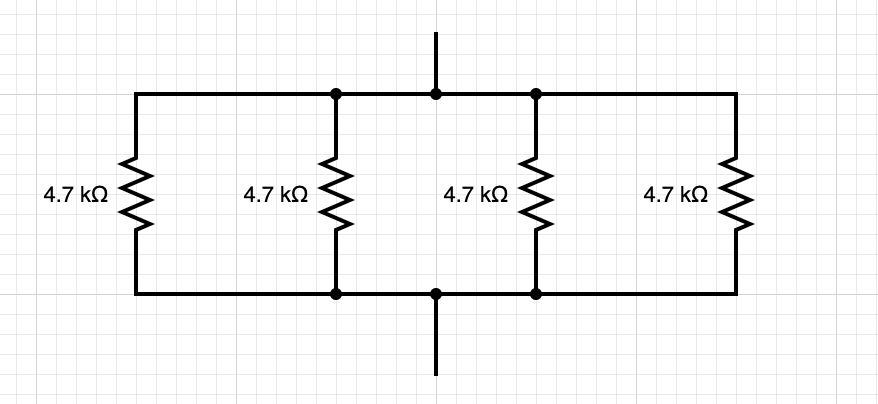

$$Conductance(G) = \frac{1}{R_{T}} = \frac{1}{R_{1}} + \frac{1}{R_{2}} + \frac{1}{R_{3}} + \frac{1}{R_{4}}$$

Then calculate the resistance based on the reciprocal:

$$Conductance(G) = \frac{4}{4700} Reciprocal = \frac{4700}{4}$$

Resistance = 1175ohms = 1.175kohms

## Power Dissipation (Watts-W)

Similar to current, Power is a measure of change over time. Instead of charge, power is the amount of energy converted into heat over time.

- When the flow of current is resisted, heat is generated
- Calculated by measuring the voltage across a load times the current flowing through it

$P = I * v$

$P = V^2 / R$

## Power Example

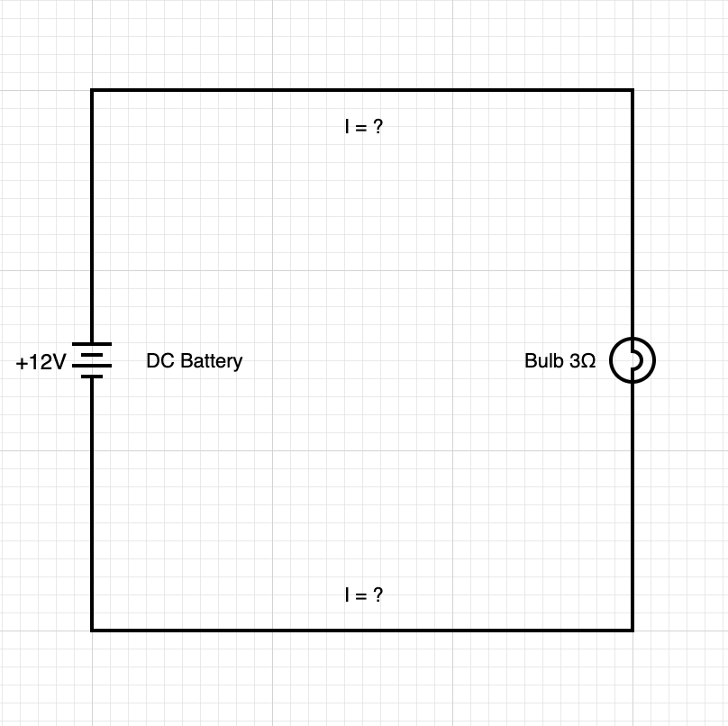

## Power Example Answer

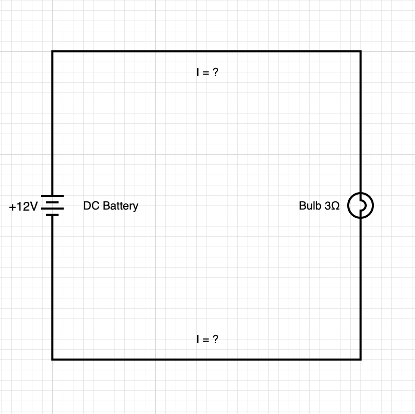

$I = 12/3 = 4$

$W = 12 * 4 = 48$

Power Dissispation = 48 Watts

## Voltage Divider

- Used to step down the voltage
- Involves a pair of resistors

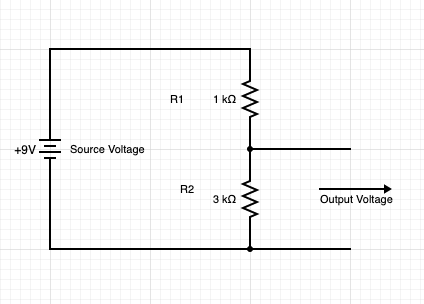

## Voltage Divider Formula

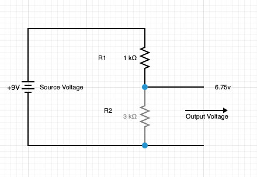

## Voltage Divider Example 1

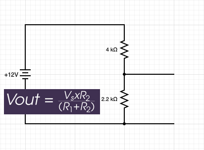

## Voltage Divider Example 1 - Answer

$$V out = \frac{V_s x R_2}{(R_1 + R_2)}$$

$$12v * 2200ohms = 26400$$

$$4000 + 2200 = 6200$$

$$26400 / 6200 = 4.26 volts$$